# —

## Setup

### Load packages

```r
library(ggplot2)
library(dplyr)
```

### Load data

Make sure your data and R Markdown files are in the same directory. When loaded your data file will be called `brfss2013`. Delete this note when before you submit your work.

```r
load("brfss2013.RData")
```

## Part 1: Data

## This is an observational study and not an experimental study because other variables are not controlled for. Random assignment is missing. This means that we can study only correlation and not causation. The data seems to be fairly generalizable (as a random population is included) to the entire population as the sample size is large and diverse in terms of demographics. However since home phone numbers were reached out to for the survey, this excludes people who do not have such a facility or might be busy at that time of the day to attend to such a call.

## Part 2: Research questions

**Research quesion 1:** Is there a correlation between individual’s weight and arthiritis diagnosis? More precisely, is there a trend in the ratio of people diagnosed positively for arthiritis to negative diagnosis as the person’s weight category increases?

Usually people with higher weight are considered to be a higher risk of arthiritis as there is more weight on the knee joints and greater wear and tear.

**Research quesion 2:** Is there a correlation between bad mental health and number of hours per week for people with mental health issues? Is there an optimum level of weekly work hours at which bad mental health could be minimised? And does financial security also play a role?

Usually people with part time employment have a lot of time to them which could result in spending more time in anxious thoughts. Also people working extremely high hours burn out and might be in poor mental health as well. I’m interested in seeing if there is an optimum level and how mental health varies with people with and without financial security.

**Research quesion 3:** Is there a correlation between bad mental health and loneliness for people with mental health issues? Is this any different for one gender when compared to another?

Doctors usually ask people with poor mental health to not be alone even if that is what they want to do. Is this effective? How does the number of people around you affect it? Is it varying for different genders with the same number of people? Let’s see!

## Part 3: Exploratory data analysis

**Research quesion 1:**

```r
library(ggplot2)
library(dplyr)

##Summarising data by groups.2 cases exist for arthiritis diagnosis(X_drdxar1) and 4 for weight categories(X_bmi5cat). A total of (2*4=8) groups exist.

q1dataset <- brfss2013 %>% filter(!is.na(X_bmi5cat),!is.na(X_drdxar1)) %>% group_by(X_drdxar1,X_bmi5cat) %>% summarise(no_of_people=n())

##Obtaining the percentage of sub-category within the larger category. First ("percentage") within the specific arthiritic condition adding the four different weight categories. Second ("percentage2") within the weight category, we find the two ratios of arthiritic to non arthiritic diagnosis.

q1dataset$percentage = signif(100*with(q1dataset, ave(no_of_people, X_drdxar1, FUN=function(x) x/sum(x))),4)

q1dataset$percentage2 = signif(100*with(q1dataset, ave(no_of_people, X_bmi5cat , FUN=function(x) x/sum(x))),4)

## Now we have refined the summary statistics further to clearly show us percentage wise breakdowns in each category.

print(q1dataset)
```

```
## # A tibble: 8 x 5
## # Groups:   X_drdxar1 [2]
##   X_drdxar1                    X_bmi5cat     no_of_people percentage percentage2
##   <fct>                        <fct>                <int>      <dbl>       <dbl>
## 1 Diagnosed with arthritis     Underweight           2376       1.51        29.0
## 2 Diagnosed with arthritis     Normal weight        41356      26.3         26.8
## 3 Diagnosed with arthritis     Overweight           54919      35.0         33.0
## 4 Diagnosed with arthritis     Obese                58459      37.2         43.6
## 5 Not diagnosed with arthritis Underweight           5828       1.91        71.0
## 6 Not diagnosed with arthritis Normal weight       112689      36.9         73.2
## 7 Not diagnosed with arthritis Overweight          111239      36.4         67.0
## 8 Not diagnosed with arthritis Obese                75591      24.8         56.4
```

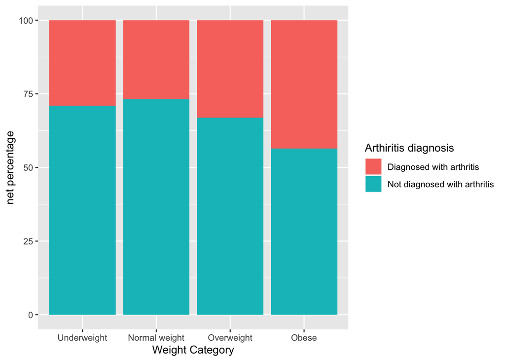

```r
## Next, Plotting the graph with these ratios obtained above. Ratios would give us a better picture as compared to absolute numbers which differ significantly for each weight category and for different arthiritis diagnosis. So differences would be better viewed with ratios in this case.

df_base <- ggplot(data = q1dataset, aes(x=X_bmi5cat ,y=percentage2, fill=X_drdxar1))
df_base + geom_bar (stat = "identity") + labs(fill="Arthiritis diagnosis") + xlab("Weight Category") + ylab("net percentage")
```

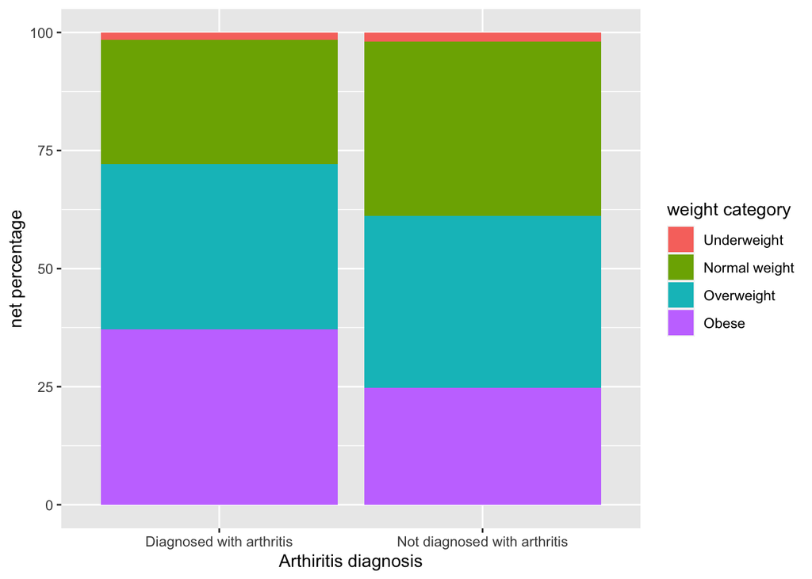

```r
df_base2 <- ggplot(data = q1dataset, aes(x=X_drdxar1 ,y=percentage, fill=X_bmi5cat))
df_base2 + geom_bar (stat = "identity") + xlab("Arthiritis diagnosis") + labs(fill="weight category") + ylab("net percentage")
```

```r
## As we can see in the first graph, a larger proportion of people are diagnosed with arthiritis as we move towards increasing weight categories. The second graph shows that among people not diagnosed with arthiritis, a larger percentage are normal weight as compared to positively diagnosed ones. Positively diagnosed category has larger percentage of people in the overweight and obese categories as compared to the undiagnosed category. Also the under weight category seems to defy this, indicating that while risk of arthiritis increases above optimum weight, it does not decrease if below optimum weight.Wow!
```

**Research quesion 2:**

```r
library(ggplot2)
library(dplyr)

## selecting columns required for the analysis ("menthlth"-which indicates no of days in a month with bad mental health. "scntwrk1","scntlwk1"- both indicate weekly hours of work and are combined to form another variable "hrs_worked" which will be later converted to categorical data "hrs_work_ctgry" for analysis in box plot. Finally "scntmeal","scntmony" which refer to -Times Past 12 Months Worried/Stressed About Having Enough Money To Pay Your Nutrition and Rent- respectively will be used to determine a new categorical variable "money_issue" indicating whether is financially troubled. So two categorical variables that have been derived will be used against the one numerical variable.

q2dataset <- brfss2013 %>% select (menthlth,scntwrk1,scntlwk1,scntmeal,scntmony)

##Next, removing cases with no data on weekly hours worked,days/month with bad mental health AND WITH 0 DAYS with bad mental health

q2dataset<- q2dataset %>% filter(!is.na(scntwrk1)|!is.na(scntlwk1),!is.na(menthlth),menthlth>0)

##Next, creating a new column with weekly hours worked and removing NA values from it.

q2dataset<- q2dataset %>% mutate(hrs_worked=ifelse(!is.na(scntwrk1),scntwrk1,scntlwk1))

##removing cases with no data on financial health

q2dataset<- q2dataset %>% filter(!is.na(scntmeal)|!is.na(scntmony))

## Obtaining a new parameter "money_issue" indicating financial health by combining two given parameters. The two parameters are refined to first remove "NA" and  the data recorded in two new parameters. These two parameters are then combined to yield the new financial health parameter of "money_issue"

q2dataset<- q2dataset %>% mutate(scntmeal_new=ifelse(!is.na(scntmeal),scntmeal,scntmony))
q2dataset<- q2dataset %>% mutate(scntmony_new=ifelse(!is.na(scntmony),scntmony,scntmeal))
q2dataset<- q2dataset %>% mutate(money_issue=ifelse(scntmeal_new==5|scntmony_new==5,"No","Yes"))

## Lets find the average and median number of days with bad mental health for our two categories of people in "money_issue" variable. Also  let's find the average weekly hours worked for each category.

q2dataset %>% filter(money_issue=="No") %>% summarise(avg_days_rich=mean(menthlth),median_days_rich=median(menthlth),avg_weekly_work_hours_rich=mean(hrs_worked))
```

```
##   avg_days_rich median_days_rich avg_weekly_work_hours_rich
## 1      8.463412                5                   42.62282
```